# Random Walk Experiment

Yuanyuan Pan

October 2, 2016

In this experiment build your intuition about probabilities associated with experiment of simulated tossing a fair coin multiple times.

## 1. Convergence of probability of tail to 0.5

Check that frequency of “Tails” (outcome equals 1) converges to 0.5 as the number of tosses grows.

**Fairness of the coin means the probability of getting a “Tail” and a “Head” are equal, as 0.5.**

If $X_i$ is an outcome number $i$ of tossing a fair coin, i.e.$X_i=1$ if the outcome is “Tails” and $X_i=0$ if the outcome is “Heads”, then trajectory of number of tails in $n$ coin tosses is

$$T(n) = \sum^n_{i=1}X_i, n = 1,...,N$$

Corresponding trajectory of frequencies of tails is

$$f(n) = \dfrac{T(n)}{n}, n = 1,...,N$$

Generate the ramdon sample, and using set.seed() to make the process reproducible.

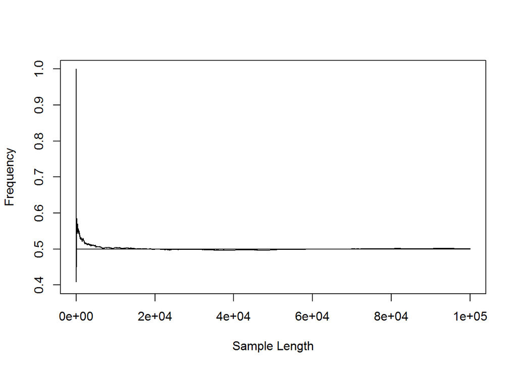

```r
set.seed(12345) # set the seed to make sure that other people can get the same result as you
nFlips = 100000 # set the how many times should they flip.
Flips<-sample(0:1,nFlips,repl=T) # generate ramdom sample
# or rbinom(nFlips,1,.5) or (runif(nFlips)<.5) # generate ramdom sample through binomial distribution
Trajectory<-cumsum(Flips) #cumulative summation
freq<-Trajectory/(1:nFlips) # calculate the cumulative frequency
plot(1:length(freq),freq, ylim=c(.4,1),type="l",ylab="Frequency",xlab="Sample Length") #make the plot of cumulative frequency
lines(c(0,nFlips),c(.5,.5)) # add the middle line with 0.5 frequency
```

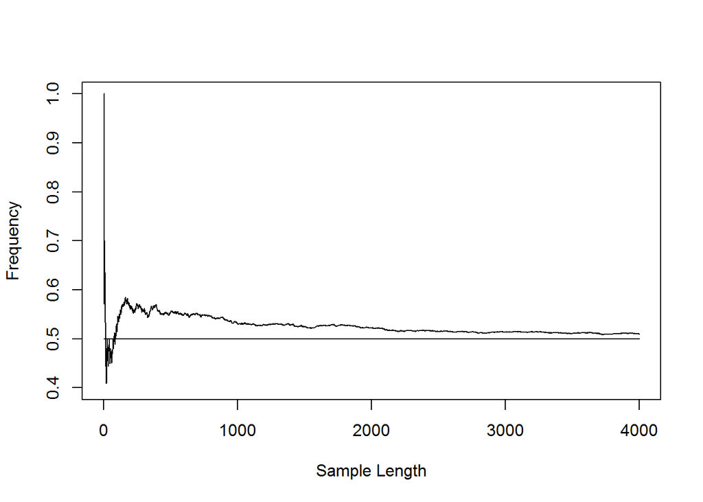

```r
plot(1:4000,freq[1:4000], ylim=c(.4,1),type="l",ylab="Frequency",xlab="Sample Length") #make the plot of cumulative frequency with less sample.
lines(c(0,4000),c(.5,.5))  # add the middle line with 0.5 frequency
```

**From the graphs we can see that then $n$ is small, the probability is far from 0.5, while as $n$ increase and become very large, the probability will converge to 0.5.**

## 2. Check your intuition about random walks

Let $X_i=1$ if the outcome of $i-th$ coin flip is “Tails” and $X_i=−1$ if the outcome is “Heads”. Cumulative sequence of $X_i$ is called a trajectory of random walk:
$$T(n) = \sum^n_{i=1} X_i, n = 1,...,N$$

### 2.1. One trajectory

Create trajectory of wealth in a game which either pays $1 with probability 0.5 or results in loss of $1 on each step.

Assume that the game is played 1,000,000 times. Use the same seed. Increase the number of flips to 1,000,000.

```r
nFlips<-1000000;
set.seed(12345)
Flips<-(sample(0:1,nFlips,repl=T)-.5)*2
```

One alternative way to generage Flips could be

```r
nFlips<-1000000;
set.seed(12345)
Flips<- (rbinom(nFlips,1,.5)-0.5)*2
```

**Intuition about random walk**

- The trajectory of wealth will deviate from zero fist, and randomly go towards one side of the zero line. As n increases, the trajectory will walk towards zero and start the similar process again. I
- in the beginning, the random walk will stay mostly on one side, while when it reach the zero line, it will stay mostly on one side again. As n increase to infinity, it could stay half above and half below, however, when n is limited, it’s hard to decide.

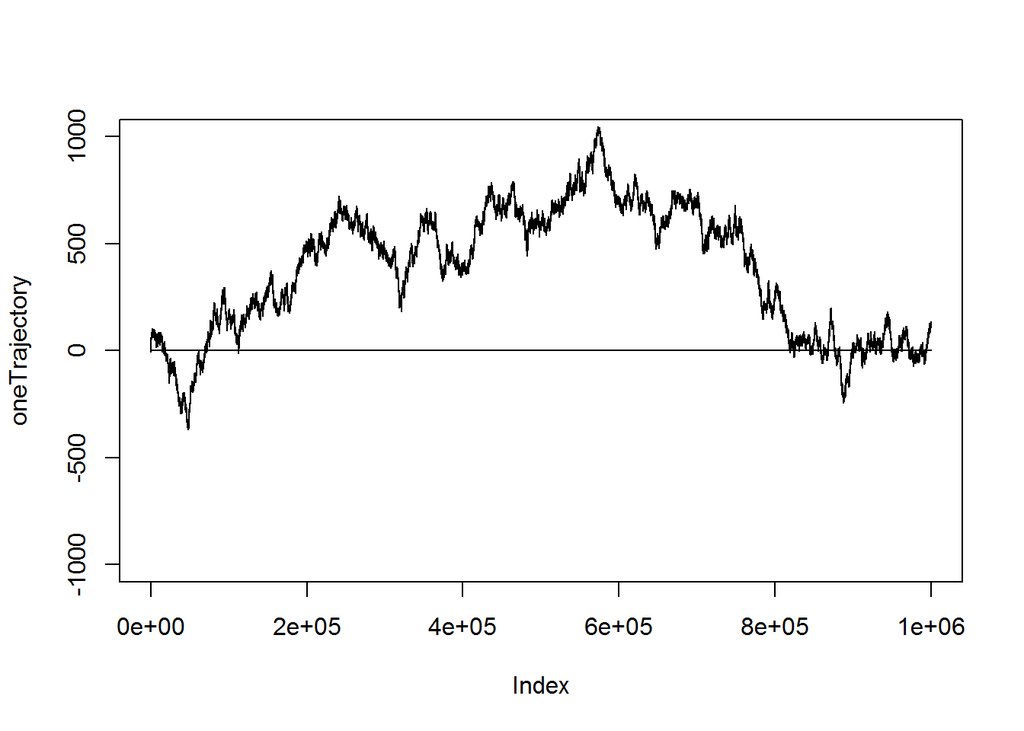

```r
oneTrajectory<-cumsum(Flips)
plot(oneTrajectory, ylim=c(-1000,1000),type="l")
lines(c(0,nFlips),c(0,0))
```

From the picture we can tell that the random walk is mostly above line 0 , although n is already large enough, which is as expected before the similation.

### 2.2 Multiple trajectories

- The probability of $P(|N_h - N_t|<5)$ in 500 coin flips is

$$P[N_h-(500-N_h)) <5 + ((500-N_h)- N_h) <5] = P( 247.5<N_h < 252.5)\\
= P( 248 \leq N_h \leq 252)$$

```r
pbinom(252,size = 500, prob = 0.5) - pbinom(248,size = 500, prob = 0.5)
```

```
## [1] 0.1418094
```

- The probability of $P(|N_h - N_t|)>25$ in 500 coin flips is

$$P[N_h-(500-N_h))>25 + P((500-N_h)- N_h)>25] = P( N_h> 262.5)+P(N_h < 237.5)\\
= P( N_h \geq 263) +P(N_h \leq 237)$$

```r
pbinom(237,size = 500, prob = 0.5) + (1 - pbinom(263,size = 500, prob =0.5))
```

```
## [1] 0.245373
```

Turn the sample Flips of 1,000,000 coin flips into 2000 random walk samples, each is 500 long. Calculate 2000 cumulative trajectories.

Each trajectory at each point shows the difference between the number of “Tails” and the number of “Heads”.

Estimate the probabilities of such deviations.

```r
Trajectories2000by500<-t(apply(matrix(Flips,ncol=500),1,cumsum))
dim(Trajectories2000by500)
```

```
## [1] 2000  500
```

```r
(probability.less.than.5<-sum(abs(Trajectories2000by500[,500])<5)/2000)
```

```
## [1] 0.18
```

```r
(probability.greater.than.25<-sum(abs(Trajectories2000by500[,500])>=25)/2000)
```

```
## [1] 0.2515
```

The probability that Trajectories end less than 5 points away from zero is 0.18 in this simulation, while the probability that Trajectories end more than 25 points away from zero is 0.25 in this simulation.

### 2.3 Time on one side

**Since random walk is a process which cannot converge, the time expected to spend on one side of zero cannot be decided**

Use matrix Trajectories2000by500 to estimate distribution of time spend by random walk on positive side.

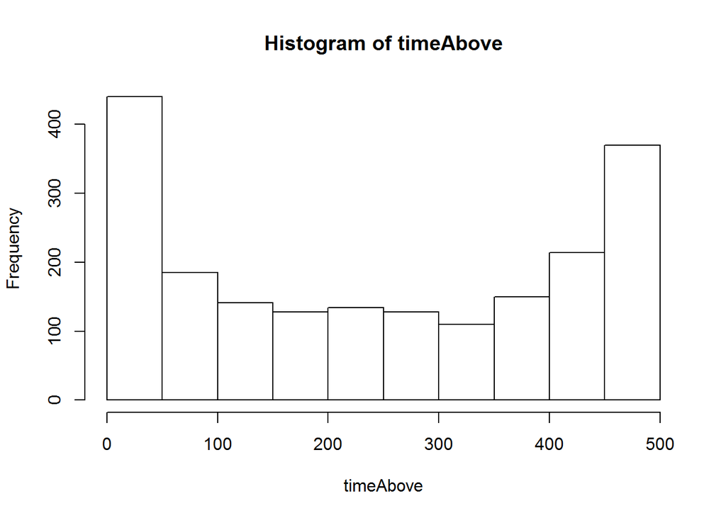

```r
timeAbove<-apply(Trajectories2000by500,1,function(z) sum(z>0))
hist(timeAbove)
```

From the result, my intuition is right.

The result shows that many random walk with 500 steps spend all the time above or below the zero line. rest of walks’ time above zero line is almost a uniform distribution. However, the mean of all those walks’ time could be around 250.